[figure not shown]

# Machine Learning I.

## Problem Set 3: Time Series Movement Prediction, Feature Engineering, and Model Comparison (14 points total)

### Instructions

The graded portion of problem set 1 consists of one notebook:

```
ps3_nb1.ipynb
```

### Due Date

- 16-FEB-2022 before 23:59:59 (CET)

### Instructor

- Prof. Dr. Gregory Wheeler (gregorywheeler.org)

### Declare your collaborators

You may work alone or in a group. The maximum group size is 4 people total.

If you work in a group, use the next cell to enter the list of names (first, last) of your collaborators.

```
# Example
COLLABORATORS = ['Stu Dent', 'May Bee', 'Ki Val Storr']
```

You should also familiarize yourself with the collaboration policy on the course Canvas page.

```python
# Be sure your names are strings
COLLABORATORS = ['Sophie Merl', 'Nicolas Kepper']
```

You have stock data for four semiconductor companies: **Analog Devices** (ADI), **Intel** (INTC), **Nvidia** (NVDA), and **Xilinx** (XLNX). This assignment will walk through some basic exploratory data analysis (EDA), preprocessing data and feature engineering, and comparing the performance of two models. This assignment is based on a paper published by ([Basak, Kar, Saha, Khaidem, and Dey 2019](https://www.sciencedirect.com/science/article/abs/pii/S106294081730400X?via%3Dihub)), which is available on Canvas.

The assignment consists of seven parts arranged in three sections:

- I. EDA
  1. Working with Dictionaries
  2. Plotting Time Series
  3. Preliminary Analysis
- II. Predicting Price Movement
  1. Exponential Smoothing
  2. Logistic Regression vs Random Forests
  3. Feature Engineering with Technical Indicators
- III. Analysis
  1. Short Answer

Each stock data set is a `.csv` formatted file covering a twenty-year history of trading data between January 15, 2000 and January 15, 2020. The next cell loads each into a [pandas](http://pandas.pydata.org/pandas-docs/stable/) dataframe. Following convention, we use the notation `df` to denote a pandas dataframe. You of course can use the `type` command to identify an object's datatype. You may also find the command `whos` helpful to list what variables are currently stored in memory, their size, and type.

```python
import numpy as np
import pandas as pd
import matplotlib.pyplot as plt

# datetime allows you to format time stamps in time series data
import datetime as dt

# load pandas dataframes
df_adi = pd.read_csv('ADI.csv')
df_intc = pd.read_csv('INTC.csv')
df_nvda = pd.read_csv('NVDA.csv')
df_xlnx = pd.read_csv('XLNX.csv')
```

# I. Exploratory Data Analysis

Before starting a supervised or unsupervised machine learning project, a critical first step is to perform **exploratory data analysis** (**EDA**) to get a preliminary understanding of your data.

A first step is to use the `.head(5)` method to inspect the first 5 entries of your 3 data frames. This code

```
df_adi.head(5)
```

returns the first 5 entries of the dataframe `df_adi`. In addition to `.head()`, you may also wish to use other methods, such as `.describe()`, which gives you descriptive statistics about the values of each of your features (columns); `.shape` which gives you the dimensions of your array; `.info()`, which gives you the data types of each feature (column), a summary of all the data types in your dataframe, and how much memory is used.

**Tip:** For this assignment, you will need to write and test some code of your own. Recall that you can add (+) or delete (scissors) highlighted cells from the toolbar:

```python
# Free Code Cell
# This command returns the version of pandas installed; but you can use it to explore your data.
pd.__version__
```

```
'1.1.5'
```

## 1) Dictionaries

Python [Dictionaries](https://docs.python.org/3/tutorial/datastructures.html#dictionaries) are a built-in data type that stores **key**-**value pairs**, just as an ordinary dictionary may be thought of as comprising a set of word-definition pairs. In ordinary dictionaries, words are arranged [lexicographically](https://en.wikipedia.org/wiki/Lexicographical_order) keys-- that is, each entry is placed in alphabetical order based on the letter components of the word. Python dictionaries (after [Python 3.6](https://docs.python.org/3/whatsnew/3.6.html#whatsnew36-compactdict)) are also ordered, in the sense that they keep the order that you use when you create them.

For example, the following dictionary, `d_min`, has as keys the stock symbol names and as values the lowest adjusted closing price for each stock.

```
d_min = {'ADI': 11.85, 'INTC': 8.58, 'NVDA': 2.26, 'XLNX': 9.88}
```

[Associative array](https://en.wikipedia.org/wiki/Associative_array) is another name for a dictionary.

You will be asked to create a very simple dictionary that associates with each of the key names used in `d_min` the respective dataframes.

**Note:** For the purposes of grading, it will be important for you to create your dictionary entries in alphabetical order, i.e., in the same key-valued order used in the example line of code for `d_min`, above.

**Student's answer(Top)**

```python
def d_maker():
    """ Returns a dictionary of stocks

    Parameters
    ----------
    :d_stocks:  dictionary
        The dictionary of stock name and stock dataframe pairs

    Returns
    -------
    :d_stocks:
    """

    d_stocks = {'ADI': df_adi, 'INTC': df_intc, 'NVDA': df_nvda, 'XLNX': df_xlnx}
    return d_stocks
```

**Grade cell: `dictionary-test` Score: 1.0 / 1.0 (Top)**

```python
# Test for d_maker
d_stocks = d_maker()
if list(d_stocks.keys())  ==  ['ADI', 'INTC', 'NVDA', 'XLNX']:
    assert True
else:
    print("ERROR in d_maker() keys:\n Check that your dictionary keys are strings, correctly spelled, and in\n alphabetical order: 'ADI', 'INTC', 'NVDA', and 'XLNX'")
    raise AssertionError("Incorrect key values.")
### BEGIN HIDDEN TESTS
from pandas.testing import assert_frame_equal
if type(assert_frame_equal(df_adi, d_stocks['ADI'], check_dtype=False)):
    assert True
else:
    raise AssertionError("Calling key 'ADI' does not return the dataframe df_adi.")
#
if type(assert_frame_equal(df_intc, d_stocks['INTC'], check_dtype=False)):
    assert True
else:
    raise AssertionError("Calling key 'INTC' does not return the dataframe df_intc.")
#
if type(assert_frame_equal(df_nvda, d_stocks['NVDA'], check_dtype=False)):
    assert True
else:
    raise AssertionError("Calling key 'NVDA' does not return the dataframe df_nvda.")
#
if type(assert_frame_equal(df_xlnx, d_stocks['XLNX'], check_dtype=False)):
    assert True
else:
    raise AssertionError("Calling key 'XLNX' does not return the dataframe df_xlnx.")
#
del assert_frame_equal
### END HIDDEN TESTS
```

## 2) Preliminary plots

Once you have a bearing on the shape of your data, the number of features, their types (e.g., integers, floats, strings, lists, Booleans, dates, et cetera), the next step in EDA often involves plotting your raw data, when possible, to give you a rough understanding of how your data is distributed.

The next block of code produces **three** plots for each stock:

- (i) a raw data histogram plot for the **Trading Volume**, plotted in red;
- (ii) the **Adjusted Closing Price**, plotted in blue; and
- (iii) the **one-day percentage change** in closing price, plotted in magenta.

When run, you should see twelve subplots, arranged in a 3x4 grid.

**Tip:** The code to produce these plots depends on your correct implementation of the function `d_maker()` above, whose output is saved to the variable `d_stocks` for you. Specifically, the two lines of code below: ~~~python keys = list(d_stocks.keys()) values = list(d_stocks.values()) ~~~ calls the dictionary `d_stocks`. The first line saves the keys of the dictionary `d_stocks` as a list, called `keys`; the second line assigns the values of the dictionary `d_stocks` to a list named `values`. If you encounter errors running the next cell, check again that `d_maker()` is creating the dictionary `d_stocks` correctly.

```
## Plot the raw Volume column from the AMD dataframe
df_adi['Volume'].plot(label='Volume', color='r', title = 'ADI', legend=True)
# x-axis label
plt.xlabel('Trading days: 2000-2020')
# y-axis label
plt.ylabel('Volume Traded')
# show the plot
plt.show()
```

You may wish to run this block to see for yourself and modify it to recreate other plots in the grid if you are uncertain about how any part of the code works.

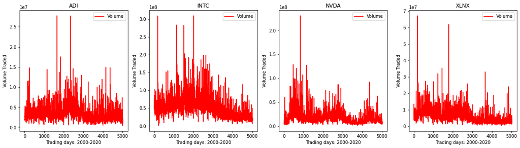

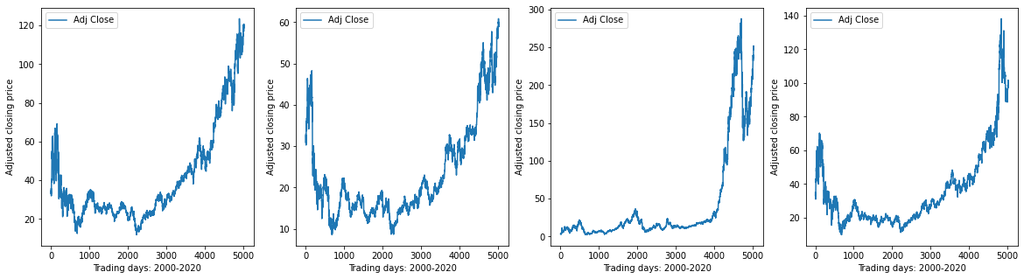

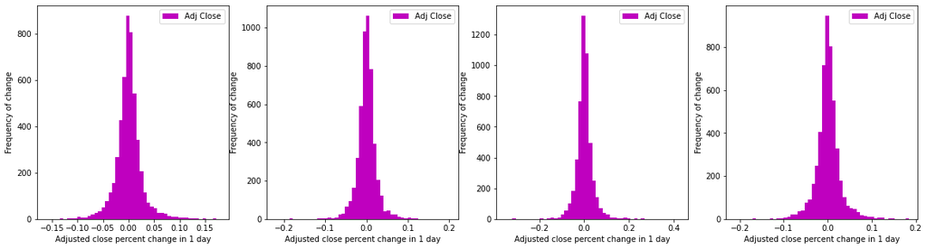

```python
# set width of plots
ww = 20
#set height of plots
hh = 5

# list of keys
keys = list(d_stocks.keys())

#list of values
values = list(d_stocks.values())

#create and populate subplots
plt.subplots_adjust(wspace=.2, hspace=.2)
plt.figure(figsize=(ww, hh))

# first row
for i in range(len(keys)):
    plt.subplot(1, len(keys), i+1)
    values[i]['Volume'].plot(label='Volume', color='r', title = keys[i], legend=True)
    #intc_df['Adj Close'].plot(label='INTC', legend=True)
    plt.ylabel('Volume Traded')
    plt.xlabel('Trading days: 2000-2020')

plt.show()  # show the plot
#plt.clf()  # clear the plot space for the next plot

# second row
plt.figure(figsize=(ww, hh))
for i in range(len(keys)):
    plt.subplot(1, len(keys), i+1)
    values[i]['Adj Close'].plot(label='Adj Close', legend=True)
    plt.ylabel('Adjusted closing price')
    plt.xlabel('Trading days: 2000-2020')

plt.show()  # show the plot
#plt.clf()  # clear the plot space for the next plot

# third row
plt.figure(figsize=(ww, hh))
for i in range(len(keys)):
# Histogram of the daily price change percent of Adj_Close
    plt.subplot(1, len(keys), i+1)
    values[i]['Adj Close'].pct_change().plot.hist(bins=50, color='m', legend=True)
    plt.xlabel('Adjusted close percent change in 1 day')
    plt.ylabel('Frequency of change')

plt.show()  # show the plot
plt.clf()  # clear the plot space for the next plot
del i # clear the index
```

## 3) Preliminary Analysis

To answer the next three questions, you may find it useful to write a few lines of code that use some built-in pandas [methods](https://pandas.pydata.org/pandas-docs/stable/reference/api/pandas.DataFrame.html) for working with dataframes, such as [.max()](https://pandas.pydata.org/pandas-docs/stable/reference/api/pandas.DataFrame.max.html#pandas.DataFrame.max), [.min()](https://pandas.pydata.org/pandas-docs/stable/reference/api/pandas.DataFrame.min.html#pandas.DataFrame.min), and perhaps even idxmax and idxmin. For Question 3, you might find both [pct_change()](https://pandas.pydata.org/pandas-docs/stable/reference/api/pandas.DataFrame.pct_change.html#pandas.DataFrame.pct_change) and [.var()](https://pandas.pydata.org/pandas-docs/stable/reference/api/pandas.DataFrame.var.html#pandas.DataFrame.var) useful.

Both Question 1 and Question 2 require you to give a list and dictionary, whereas Question 3 is a multiple choice, multiple answer question.

## Question 1

What is the correct ordering of stocks by their maximum volume, from highest to lowest? Complete the function `ans_one()` with your answer. Specifically, you need to find the maximum trading-day volume of each stock then order a list of the stock names,

```
['ADI', 'INTC', 'NVDA', 'XLNX']
```

by their respective maximum trading volumes, from highest volume to lowest.

Provide two lines of code to specify the variables `d_list` and `d_max`:

```
d_list =   # a list, stock symbol names ordered max volume to min volume
d_max =   # a dictionary, ordered max volume to min volume
```

### Q1 Answer:

**Student's answer(Top)**

```python
def ans_one():
    """ Returns a list of stocks ordered by volume
        and a dictionary ordered by volume.

    Parameters
    ----------
    :d_list:  list
        The list of stock symbol names ordered by volume,  max to min
    :d_max:   dictionary
        The dictionary of stocks ordered by volume, max to min

    Returns
    -------
    :d_list:
    :d_max:
    """

    d_list = ['INTC', 'NVDA', 'XLNX', 'ADI']
    d_max = {'INTC': df_intc['Volume'].max(), 'NVDA': df_nvda['Volume'].max(),
             'XLNX': df_xlnx['Volume'].max(), 'ADI': df_adi['Volume'].max()}
    return d_list, d_max
```

**Grade cell: `ans_one-answer` Score: 0.0 / 0.0 (Top)**

```python
# Test cell
### BEGIN HIDDEN TESTS
# This cell simply prints the answer
d = {}
stock_dict = {'ADI': df_adi, 'INTC': df_intc, 'NVDA': df_nvda, 'XLNX': df_xlnx}
for key, val in stock_dict.items():
    k, v = (key,  val['Volume'].max())
    d[k] = v

print("QUESTION 1.\n The max-to-min ordering is:")
for k in sorted(d, key=d.get, reverse=True):
    print("", k,"\t", d[k])
del k
del v
del key
del val
del stock_dict
### END HIDDEN TESTS
```

```
QUESTION 1.
 The max-to-min ordering is:
 INTC 	 309347600
 NVDA 	 230771400
 XLNX 	 67156700
 ADI 	 27748000
```

**Grade cell: `ans_one-test1` Score: 1.0 / 1.0 (Top)**

```python
# Test cell
d_list, d_max = ans_one()
if (type(d_list) == list and type(d_max) == dict):
    assert True
else:
    print("ERROR: Check that `d_list` is a list, and `d_max` a dictionary")
    raise AssertionError("Type error: executing ans_one() should return a list and dict")
### BEGIN HIDDEN TESTS
dd_list, dd_max = ans_one()
if dd_list == ['INTC', 'NVDA', 'XLNX', 'ADI']:
    assert True
else:
    raise AssertionError("Error in d_list.")
del dd_list
del dd_max
del d_list
del d_max
### END HIDDEN TESTS
```

**Grade cell: `ans_one-test2` Score: 1.0 / 1.0 (Top)**

```python
# Test cell
### BEGIN HIDDEN TESTS
dd_list, dd_max = ans_one()
# Test d_max
if (dd_max['INTC']== 309347600 and dd_max['NVDA'] == 230771400 and dd_max['XLNX'] == 67156700 and dd_max['ADI'] == 27748000):
    assert True
else:
    raise AssertionError("Error in d_max values")
del d
del dd_list
del dd_max
### END HIDDEN TESTS
```

## Question 2

What is the correct ordering of the list of stocks by their maximum Adjusted Closing Price, from highest to lowest?

Complete the function `ans_two()` with your answer. Specifically, you need to provide two lines of code specify the variables `d_list` and `d_max`:

```
d_list =   # a list, stock symbol names ordered Adjusted Closing Price, max to min
d_max =   # a dictionary, Adjusted Closing Price, max to min
```

The grader will evaluate adjusted closing price rounded to two decimal places using Python's built-in round function.

### Q2 Answer:

**Student's answer(Top)**

```python
def ans_two():
    """ Returns a list of stocks ordered by Adjusted Closing Price
        and a dictionary ordered by Adjusted Closing Price.

    Parameters
    ----------
    :d_list:  list
        The list of stock symbol names ordered by Adj Close,  max to min
    :d_max:   dictionary
        The dictionary of stocks ordered by Adj Close, max to min

    Returns
    -------
    :d_list:
    :d_max:
    """
    d_list = ['NVDA', 'XLNX', 'ADI', 'INTC']
    d_max = {'NVDA': df_nvda['Adj Close'].max(), 'XLNX': df_xlnx['Adj Close'].max(),
             'ADI': df_adi['Adj Close'].max(), 'INTC': df_intc['Adj Close'].max()}
    return d_list, d_max
```

**Grade cell: `ans_two-answer` Score: 0.0 / 0.0 (Top)**

```python
# Test cell
### BEGIN HIDDEN TESTS
d = {}
stock_dict = {'ADI': df_adi, 'INTC': df_intc, 'NVDA': df_nvda, 'XLNX': df_xlnx}
for key, val in stock_dict.items():
    k, v = (key,  val['Adj Close'].max())
    d[k] = v

print("QUESTION 2.\n The max-to-min ordering is:")
for k in sorted(d, key=d.get, reverse=True):
    print("", k, "\t", round(d[k],2))
del k
del v
del key
del val
del stock_dict
### END HIDDEN TESTS
```

```
QUESTION 2.
 The max-to-min ordering is:
 NVDA 	 287.95
 XLNX 	 138.25
 ADI 	 123.43
 INTC 	 60.84
```

**Grade cell: `ans_two-test1` Score: 1.0 / 1.0 (Top)**

```python
# Test cell
d_list, d_max = ans_two()
if (type(d_list) == list and type(d_max) == dict):
    assert True
else:
    print("ERROR: Check that `d_list` is a list, and `d_max` a dictionary")
    raise AssertionError("Type error: executing ans_one() should return a list and dict")
### BEGIN HIDDEN TESTS
dd_list, dd_max = ans_two()
if dd_list == ['NVDA', 'XLNX', 'ADI', 'INTC']:
    assert True
else:
    raise AssertionError("Error in d_list.")
del dd_list
del dd_max
del d_list
del d_max
### END HIDDEN TESTS
```

**Grade cell: `ans_two-test2` Score: 1.0 / 1.0 (Top)**

```python
# Test cell
### BEGIN HIDDEN TESTS
dd_list, dd_max = ans_two()
if dd_list == ['NVDA', 'XLNX', 'ADI', 'INTC']:
    assert True
else:
    raise AssertionError("Error in d_list.")
# Test d_max
if (round(dd_max['NVDA'],2) == 287.95 and round(dd_max['XLNX'],2) == 138.25
    and round(dd_max['ADI'],2) == 123.43 and round(dd_max['INTC'],2) == 60.84):
    assert True
else:
    raise AssertionError("Error in d_max values")
del d
del dd_list
del dd_max
### END HIDDEN TESTS
```

## Question 3

Each stock has a peak price, $P_1$, which you calculated to answer Question 2. Following $P_1$, there is a minimum price or trough, $T$. Following $T$ there may be another peak, $P_2$, called the **rebound recovery price**. For purposes of the next question we say that the **rebound recovery percentage** *(RRP)* of a stock is calculated by

$$ RRP := \frac{P_2}{P_1} $$

which is 1.00 if $P_2 = P_1$.

Which of the following are true? Select all and only that apply.

- A) None of the stocks have seen their closing price drop more than 50% after their peak price.
- B) ADI has the highest rebound recovery.
- C) XLNX has the highest rebound recovery.
- D) NVDA has the highest variance in one-day percentage price change.
- E) INTC has the lowest variance in one-day percentage price change.
- F) None of the above are true

From the list of possible answers `['A', 'B', 'C', 'D', 'E', 'F']`, complete the next function with a list of your answer(s).

### Q3 Answer:

**Student's answer(Top)**

```python
def ans_three():
    """ Returns a list of your answers.

    Parameters
    ----------
    :ans:  list
        The list of your answers. Elements of :ans: are strings.
    Returns
    -------
    :ans:
    """

    ans = ["D", "E"]
    return ans
```

**Grade cell: `ans_three-answer` Score: 0.0 / 0.0 (Top)**

```python
# Test cell
### BEGIN HIDDEN TESTS
df_list = values
names = keys
for i in range(len(keys)):
    idx_peak  = df_list[i]['Adj Close'].idxmax()
    peak = df_list[i]['Adj Close'][idx_peak]
    idx_low = df_list[i]['Adj Close'][idx_peak : -1].idxmin()
    low = df_list[i]['Adj Close'][idx_low]
    rebound = df_list[i]['Adj Close'][idx_low : -1].max()
    var = df_list[i]['Adj Close'].pct_change().var()
    drop = (peak -low)/peak
    #print("---" + names[i] +"---")
    print(names[i] + ": \t" + "P1: " + str(round(peak, 2)) + "\tT: " + str(round(low,2)) + \
          "\tP2: " + str(round(rebound,2)) + "\t RRP: " + \
          str(round(rebound/peak,3)) + "\t%drop: " + str(round(drop, 2)) +  "\tVar: "+ str(round(var,5)) +"\n")

del i, idx_peak, idx_low, low, rebound, var
print("Question 3: the correct answers are [D, E]. ")

### END HIDDEN TESTS
```

```
ADI: 	P1: 123.43	T: 103.16	P2: 120.66	 RRP: 0.978	%drop: 0.16	Var: 0.00069

INTC: 	P1: 60.84	T: 58.93	P2: 59.59	 RRP: 0.979	%drop: 0.03	Var: 0.00053

NVDA: 	P1: 287.95	T: 126.59	P2: 251.98	 RRP: 0.875	%drop: 0.56	Var: 0.00146

XLNX: 	P1: 138.25	T: 88.65	P2: 101.65	 RRP: 0.735	%drop: 0.36	Var: 0.00078

Question 3: the correct answers are [D, E].
```

**Grade cell: `ans_three-test1` Score: 1.0 / 1.0 (Top)**

```python
# Test cell to check the format of your answer
ans = ans_three()
%run -i 'ans_format_test.py'
### BEGIN HIDDEN TESTS

# Test
ans = [x.upper() for x in ans]
if 'D' in ans and 'E' in ans and len(ans) == 2:
    assert True
else:
    raise AssertionError("Incorrect answer.")
del ans
del possible_ans
### END HIDDEN TESTS
```

# II. Predicting Movement

In this section you will run two classification models on the smoothed data, then do some feature engineering and rerun the same two models on your stock data with those new features.

Your task then is to compare the performance of predicting the movement of your stocks using a **logistic regression model** and a **random forest model**.

## 4) Exponential Smoothing

The first step is to preprocess data by **exponential smoothing**. The smoothed statistic $s_t$ at time $t$ is an function of the current observation, $x_t$, and previous observations $x_{t-1}, x_{t-2},\ldots, x_0$, and the smoothing factor $\alpha$:

$$ s_t = \frac{x_t + (1-\alpha)x_{t-1}+(1-\alpha)^2x_{t-2}+\cdots+(1-\alpha)^tx_0}{1+(1-\alpha)+(1-\alpha)^2 + \cdots + (1-\alpha)^t}$$

This equation is the [adjusted version](https://pandas.pydata.org/pandas-docs/stable/user_guide/computation.html#exponentially-weighted-windows) of the exponential weighted window for finite histories, which is the default used by the python `ewm()` method. The smoothing factor $\alpha$ takes values between $0$ and $1$ (excluding 0), where it should be clear that $s_t = x_t$ if $\alpha = 1$, which corresponds to no smoothing.

```python
# remove 'Date' and 'Adj Close' features from each stock dataframe
for key, value in d_stocks.items():
    #
    del(value['Date'])
    del(value['Adj Close'])
```

Your next task is to finish the function, `exp_smooth()`, using the pandas [.ewm method()](https://pandas.pydata.org/pandas-docs/stable/reference/api/pandas.DataFrame.ewm.html) and [.mean()](https://docs.scipy.org/doc/numpy/reference/generated/numpy.mean.html) to calculate **exponential weighted average** of a dataframe.

The `ewm()` method has a number of adjustable parameters, but for this task you should only use the smoothing factor $\alpha$, which takes values between 0 and 1. To be explicit, your use of this method should be of the following form:

```
df.ewm(alpha=alpha)
```

applied here to some data frame `df`.

For this task, you need to attend to two things. First, to complete the function, you need to supply one line of code to compute exponential smoothing to `df`, a datframe, assigned to the local variable `smoothed_df`:

```
def exp_smooth(df, alpha=0.5):
    """ Returns the exponential weighted average of a dataframe

        Parameters
        ----------
        :df: dataframe
            The input dataframe
        :alpha: float
            The smoothing factor|

        Returns
        -------
        :smoothed_df: dataframe
            The exponential weighted average of df with smoothing alpha
    """

    # YOUR ANSWER HERE
    smoothed_df =  ## finish your line of code here

    return smoothed_df
```

Second, the smoothing factor default value (when one is not specified) is set to 1/2:

```
alpha=0.5
```

Values for `alpha` (using a variable named `ta_alpha`, below) will be adjusted by you later in the assignment.

**Student's answer(Top)**

```python
def exp_smooth(df, alpha=0.5):
    """ Returns the exponential weighted average of a dataframe

        Parameters
        ----------
        :df: dataframe
            The input dataframe
        :alpha: float
            The smoothing factor|

        Returns
        -------
        :smoothed_df: dataframe
            The exponential weighted average of df with smoothing alpha
    """

    smoothed_df = df.ewm(alpha=alpha).mean()
    return smoothed_df
```

**Grade cell: `expo_smooth-test` Score: 1.0 / 1.0 (Top)**

```python
# public test condition: the exponential weighted average of the
# Opening price of ADI on day 1000 with default alpha = 0.5 rounded
# to 3 decimal places is 48.823:

if round(exp_smooth(df_adi)['Open'][1000], 3) == 48.823:
    assert True
else:
    print("Error: Check that your exp_smooth() function is implemented correctly.")
    raise AssertionError("Incorrect answer.")
### BEGIN HIDDEN TESTS
df_test = pd.DataFrame({'B': [0, 1, 2, 3, 4], 'C': [2, 6, 10, 4, 8]})

if round(exp_smooth(df_test,0.324)['C'][2], 3) == 7.018:
    assert True
else:
    print("Error: Check that your function works for any dictionary with numerical values and any alpha in (0, 1].")
    raise AssertionError("Incorrect answer.")
del df_test

### END HIDDEN TESTS
```

## 5) Direction-Prediction with Logistic Regression and Random Forests

In this part, you will construct two models that predict the direction of stock prices realizing a gain ($y = 1$) or loss ($y=0$). Specifically, you will compare the performance of a logistic regression classifier, which you have worked with already, to an ensemble of CART classification models, otherwise known as a **random forest** classifier.

Predicting returns is typically posed as a forecasting regression problem, where prices are predicted. The problem may nevertheless be posed as a classification problem which predicts whether a stock price will increase ($y = 1$) or decrease ($y=0$). The model you will develop here is adapted from an approach taken by ([Basak, Kar, Saha, Khaidem, and Dey 2019](https://www.sciencedirect.com/science/article/abs/pii/S106294081730400X?via%3Dihub)), and is markedly different than standard time-series methods:

"Standard models used in stock price forecasting involves statistical methods such as time series modeling and multivariate analysis ... where the stock price movements are usually treated as a function of time and solved as a regression problem. Conversely, in this paper as we pose it as a classification problem, the class label of each sample is determined by considering the t-day return. In our analysis, we have conducted experiments on t = 3, 5, 10, 15, 30, 60, and 90 days. The goal is to design an intelligent model that learns from the market data using machine learning techniques and predicts the direction in which a stock price will change at the closing time everyday. The ability to forecast direction of stock prices for individuals and companies capable of holding on to investments over medium to long-run should be a very useful support to this literature" (Basak et al. 2019, p. 553).

From this point on, you will be modifying your stock data frames, by adding new columns (features), and later, for step 6, smoothing the original data with different values of the smoothing factor $\alpha$. The next code cell collects together some code to be run all at once under a particular value for `alpha` in an effort to help ensure that smoothing is *only applied once*.

**Tip:** Because you are making modifications to your datasets, it is a good idea to clear and rerun the notebook as you complete each task to make sure your code runs without errors from the start.

```python
# Copy stock dataframes
adi = df_adi
intc = df_intc
nvda = df_nvda
xlnx = df_xlnx

# Stock dictionary used for smoothing and feature engineering.
s_stock_d = {'ADI': adi, 'INTC': intc, 'NVDA': nvda, 'XLNX': xlnx}

# smoothing factor
alpha = .5

# apply smoothing to all stocks in dict
for key, value in s_stock_d.items():
        s_stock_d[key] = exp_smooth(value,alpha)
```

Your next task is to compare the closing price from $n$-days ago to the current closing price. Let's treat a loss as the event of interest (i.e., $y=1$). So, if the $n$-day ago price is strictly greater than the current price, then `pred = 1`; otherwise, `pred = 0`.

To effect this comparison, you may wish to use the [.shift(-n)](https://pandas.pydata.org/pandas-docs/stable/reference/api/pandas.DataFrame.shift.html) method, where $n$ is an integer used to specify the number of trading days the index will be shifted. For example, you may wish to compare the Series

```
adi.shift(-1)['Close']
```

to

```
adi['Close']
```

Compute these values so that you understand exactly what is being compared to what.

Your task is to write one line of code to produce a Series consisting of a column of 1's and 0's, saved to the local variable `pred`, that will serve as your vector of classification labels. In other words, the Series `pred` stores $y^{(i)} = 1$ or $y^{(i)} = 0$ for each day $i$.

```
def prediction_int(df, n):
    """ Returns an integer label for n day closing price losses/gains.

    Parameters
    ----------
    :df:     dataframe
        A stock dataframe
    :n:      int
        The prediction horizon in days

    Returns
    -------
    :data:   series
        The single column of integer predictions:
    """
    # YOUR ANSWER HERE
    pred =  #YOUR CODE HERE    # Hint: returns 1 if a loss, 0 otherwise

    pred = pred.iloc[:-n]
    return pred.astype(int)
```

**Student's answer(Top)**

```python
def prediction_int(df, n):
    """ Returns an integer label for n day closing price losses/gains.

    Parameters
    ----------
    :df:     dataframe
        A stock dataframe
    :n:      int
        The prediction horizon in days

    Returns
    -------
    :data:   series
        The single column of integer predictions
    """
    # YOUR CODE HERE
    pred = pred = df['Close'] < df.shift(-n)['Close']
    pred = pred.iloc[:-n]
    return pred.astype(int)
```

```python
# A companion cell to the public test cell 'pred_int_test'
print("Close on target day 256:\t {}".format(intc['Close'][256]))
print("Close on prior day 256-8:\t {}".format(intc.shift(-8)['Close'][256]))
print("You say 'Prior > Target' is:\t {}".format(prediction_int(intc,8)[265].astype(bool)))
```

```
Close on target day 256:	 35.375
Close on prior day 256-8:	 35.6875
You say 'Prior > Target' is:	 True
```

**Grade cell: `pred_int_test` Score: 1.0 / 1.0 (Top)**

```python
#
if prediction_int(intc,8)[265] == 1:
    assert True
else:
    raise AssertionError("The function predict_int is not implemented correctly.")
### BEGIN HIDDEN TESTS
if prediction_int(nvda,6)[207] == 1:
    assert True
else:
    raise AssertionError("The function predict_int is not implemented correctly.")
### END HIDDEN TESTS
```

```python
def prepare_data(df, days):
    """ Adds prediction vector and prepares data

    Parameters
    ----------
    :df:     dataframe
        A stock dataframe
    :days:   int
        The prediction horizon in days

    Returns
    -------
    :data:   dataframe
    """

    data = df.dropna().iloc[:-days]
    data['pred'] = prediction_int(data, n=days)
    del(data['Close'])
    return data.dropna()
```

Here is a block of code that operates on a single data frame `df = s_stock_d['ADI']` and a particular time window `days = 7` to produce a target vector of 1s and 0s, `y = data['pred']`, and the features of the `data` without labels, `X = data.drop('pred',axis =1)`:

```
#prepare ADI stock data with 7 day forecast window
data = prepare_data(s_stock_d['ADI'], 7)

# create target label vector
y = data['pred']

# create features by removing the target labels
X = data.drop('pred',axis =1)
```

You will be asked, below, to evaluate *all* stocks. So, it will be more efficient to write some code using [iterators](https://wiki.python.org/moin/Iterator) to generalize this preparation step to prepare all stocks in the dictionary `s_stocks_d`. The next cell should be used to complete such a function.

**Student's answer(Top)**

```python
def features_targets_dict(d, days):
    """ Prepares a dictionary that stores the target Series y
        and features Dataframe X with a prediction window (days)
        for dictionary of stock Dataframes (d)

    Parameters
    ----------
    :d:     dictionary
        A dictionary of stocks whose values are dataframes
    :days: int
        The prediction horizon in days

    Returns
    -------
    :datasets:    dictionary of labaled datasets for each stock
    :targetsets:  dictionary of target label vectors for each stock
    :featuresets: dictionary of unlabeled datasets for each stock
    """

    # dictionary data prep
    datasets = {}
    targetsets = {}
    featuresets = {}
    for k in d.keys():
        datasets[k] = prepare_data(d[k],days)
        targetsets[k] = datasets[k]['pred']
        featuresets[k] = datasets[k].drop('pred',axis =1)
    return datasets, targetsets, featuresets
```

**Important:** The next test cells for **features_targets_dict()** assume that **alpha = 0.5**. The public test conditions will produce an error if you preprocess your data with a different value for alpha.

**Grade cell: `features-targets-test` Score: 1.0 / 1.0 (Top)**

```python
# features_targets_dict() test
datasets, targetsets, featuresets = features_targets_dict(s_stock_d, 7)
if round(datasets['ADI']['Open'][55], 3) == 74.289  and round(datasets['NVDA']['Open'][555], 3) == 13.884:
    assert True
else:
    print("Hint: check that you are iterating over all the stock dataframes")
    raise AssertionError("Error in features_targets_dict()")

if targetsets['ADI'].isnull().values.any() == False:
    assert True
else:
    print("Your targetset contains NaNs. Hint: Try using the .dropna() method.")
    raise AssertionError("Error in targetsets")
### BEGIN HIDDEN TESTS
if round(datasets['INTC']['Open'][728], 4) == 18.157 and round(datasets['ADI']['Low'][1720], 4)  == 33.134:
    assert True
else:
    print("Your code for features_targets_dict() fails one of two hidden tests")
    raise AssertionError("Error in features_targets_dict()")
### END HIDDEN TESTS
```

### Scikit-Learn

Recall the workflow logic and API format for sklearn. Once libriaries are imported, you should prepare your data, split into a **training set** and **test set**, fit a model on your training set, perform predictions on your test set, then evaluate the results with an appropriate numerical performance measure.

To help you, here is some code that will run on a *single dataframe*. Given the questions you will be asked to consider, you will want to adapt this to iterate over all items of your stock dictionary, and perhaps even iterate over the models you are comparing. Ideally, you should collect together the results of your model in a single dataframe that stores all the results in one table. How you choose to solve the problem, however, is up to you.

### Sample code for producing a Random Forest Model.

```
# Data Prep: use features_targets_dict(); select a data frame df
y   # the target labels of df
X   # the features of df

# Used to find the 70/30 split point
train_set_split = int(len(X) * 0.7)

# Training and test sets
X_train = X[:train_set_split]
X_test = X[train_set_split:]
y_train = y[:train_set_split]
y_test = y[train_set_split:]

# Create Random Forest Classifier object
clf = RandomForestClassifier(n_jobs=-1, n_estimators=60, random_state=212)

# Train the model using the training sets
clf.fit(X_train, y_train)

# Predictions using test features
pred = clf.predict(X_test)

# Performance Measures
precision = precision_score(y_pred=pred, y_true=y_test)
recall = recall_score(y_pred=pred, y_true=y_test)
f1 = f1_score(y_pred=pred, y_true=y_test)
accuracy = accuracy_score(y_pred=pred, y_true=y_test)
confusion = confusion_matrix(y_pred=pred, y_true=y_test)

# Display Results
print('precision: {0:1.2f}, recall: {1:1.2f}, f1: {2:1.2f}, accuracy: {3:1.2f}'.format(precision, recall, f1, accuracy))
print('Confusion Matrix')
print(confusion)
```

### Important for Your Implementation:

For a **random forest** model, you must instantiate `RandomForestClassifier()` using the following parameters

```
clf_rf = RandomForestClassifier(n_jobs=-1, n_estimators=60, random_state=212)
```

For a **logistic regression** model, you must instantiate `LogisticRegression()` without parameters, that is as

```
clf_lr = LogisticRegression()
```

The variable names `clf_rf` and `clf_lr` are local and so can vary; we include each to ensure each line of code is in an executable form.

Lastly, a **70/30 split** for training/test sets **must be used**; it is therefore *strongly recommended* to incorporate the following line of code to ensure a standardized 70/30 split:

```
train_set_split = int(len(X) * 0.7)
```

**Important:** To ensure standardized answers, you **must** use these parameter settings and only these settings. In addition, we are continuing to use a 7-day window and `alpha = 0.5`.

The next cell loads models and metrics from sklearn.

```python
# scikit-learn libraries
from sklearn.linear_model import LogisticRegression
from sklearn.ensemble import RandomForestClassifier
from sklearn.model_selection import train_test_split
from sklearn.metrics import f1_score, precision_score, confusion_matrix, recall_score, accuracy_score
```

Using sklearn, you should build relevant models to answer the next and subsequent questions.

## Question 4

There are four stocks (ADI, INTC, NVDA, XLNX) and two classification models (Logistic Regression, Random Forest). Pre-process your data using a **7-day window** and smoothing factor $\alpha = 0.5$. What is the ranking of the accuracy results (rounded to 3 decimal places) of the resulting 8 models, from best to worst?

To answer this question, you will need to supply a dictionary whose **keys** are from the following list:

```
# keys for the dictionary returned by ans_four()
['ADI LR','INTC LR', 'NVDA LR', 'XLNX LR', 'ADI RF','INTC RF', 'NVDA RF', 'XLNX RF']
```

and whose **values** are the accuracy scores of each model, rounded to 3 decimal places. To be clear, 'LR' stands for a logistic regression model, 'RF' a random forest model. Thus, within the dictionary `d_acc` returned by `ans_four()`, `'ADI LR'` is the dictionary key value used to refer to the accuracy score of a logistic regression classification model for the ADI stock. Your answer to Question 4 will be a line of code for `ans_four()` of the following generic form:

```
d_ans = {'Key_1': 0.000, 'Key_2': 0.000, 'Key_3': 0.000, 'Key_4': 0.000,
         'Key_5': 0.000, 'Key_6': 0.000, 'Key_7': 0.000, 'Key_8': 0.000}
```

To avoid mistyped answers, you may wish to copy-and-paste each key from the list of keys above. To ensure your dictionary **values** pass the tests correctly, your accuracy scores should be rounded to 3 decimal places using

```
# code that will be used to test your key values.
round(acc, 3)
```

wherel `acc` is the accuracy score for each of the eight models.

### Q4 Answer:

**Student's answer(Top)**

```python
def ans_four():
    """ Returns a dictionary ordered by accuracy.

    Parameters
    ----------
    :d_acc:   dictionary
        The dictionary of stocks ordered by accuracy score to 3 decimal places, max to min

    Returns
    -------
    :d_acc:
    """

    d_acc = {'NVDA LR': 0.609, 'ADI LR': 0.564, 'XLNX LR': 0.543, 'XLNX RF': 0.508,
             'INTC RF': 0.496, 'ADI RF': 0.427, 'INTC LR': 0.425, 'NVDA RF': 0.416}

    return d_acc
```

**Grade cell: `ans_four-answer` Score: 0.0 / 0.0 (Top)**

```python
# Test cell
### BEGIN HIDDEN TESTS
days = 7
datasets, targetsets, featuresets = features_targets_dict(s_stock_d, days)

num_trees = 60

models = {"Logistic Regression": LogisticRegression(),
          "Random Forest Classifier": RandomForestClassifier(n_jobs=-1, n_estimators=num_trees, random_state=212)}

res = {}
for name, stock_df in datasets.items():
    for model_name, model in models.items():
        # Data Prep
        y = stock_df['pred'].dropna()
        X = stock_df.drop('pred',axis=1)

        # Training and test sets
        train_set_split = int(len(X) * 0.7)
        X_train = X[:train_set_split]
        X_test = X[train_set_split:]
        y_train = y[:train_set_split]
        y_test = y[train_set_split:]

        # Models
        n = name + " "+ model_name + " " + str(days) + "-day window "
        clf = model
        clf.fit(X_train, y_train)
        pred = clf.predict(X_test)

        # Metrics
        accuracy = accuracy_score(y_pred=pred, y_true=y_test)
        #precision = precision_score(y_pred=pred, y_true=y_test)
        recall = recall_score(y_pred=pred, y_true=y_test)
        f1 = f1_score(y_pred=pred, y_true=y_test)
        confusion = confusion_matrix(y_pred=pred, y_true=y_test)

        # Results
        res[n] = {"Accuracy": accuracy, "Recall": recall, \
                      "F1 Score": f1, "Confusion": confusion}

results = pd.DataFrame.from_dict(res, orient="index")
results = results[["Accuracy", "Recall", "F1 Score"]]
print("Question 4: All eight models ordered by accuracy scores:")
round(results['Accuracy'].sort_values(ascending=False),3)
### END HIDDEN TESTS
```

```
Question 4: All eight models ordered by accuracy scores:
```

```
NVDA Logistic Regression 7-day window          0.609
ADI Logistic Regression 7-day window           0.564
XLNX Logistic Regression 7-day window          0.543
XLNX Random Forest Classifier 7-day window     0.508
INTC Random Forest Classifier 7-day window     0.496
ADI Random Forest Classifier 7-day window      0.427
INTC Logistic Regression 7-day window          0.425
NVDA Random Forest Classifier 7-day window     0.416
Name: Accuracy, dtype: float64
```

**Grade cell: `ans_four-test-1` Score: 1.0 / 1.0 (Top)**

```python
d_acc = ans_four()
if (type(d_acc) == dict and len(d_acc) == 8):
    assert True
else:
    print("ERROR: Check that `d_acc` is a dictionary with 8 items")
    raise AssertionError("Error: ans_four()")

### BEGIN HIDDEN TESTS


# check order & syntax
if list(d_acc.keys()) == ['NVDA LR', 'ADI LR', 'XLNX LR', 'XLNX RF',
                          'INTC RF', 'ADI RF', 'INTC LR','NVDA RF']:
    assert True
else:
    print("ERROR: The models are not in the correct order or keys are improperly formated.")
    raise AssertionError("Error: ans_four()")

# check key values
if (d_acc['NVDA LR']== 0.609 and d_acc['ADI LR'] == 0.564 and
    d_acc['XLNX LR'] == 0.543 and d_acc['XLNX RF'] == 0.508 and
    d_acc['INTC RF'] == 0.496 and d_acc['ADI RF'] == 0.427 and
    d_acc['INTC LR'] == 0.425 and d_acc['NVDA RF'] == 0.416):
    assert True
else:
    print("ERROR: At least one of the 8 accuracy scores is incorrect.")
    raise AssertionError("Error: ans_four()")
del d_acc

### END HIDDEN TESTS
```

## Question 5

Multiple choice questions. Select all and only that are true.

- A) A random forest model produces the lowest F1 score
- B) NVDA Logistic Regression has the highest Accuracy, Precision, Recall, and F1 Score
- C) All random forest models have a precision score greater than 0.5.
- D) No random forest model has an F1 score above 0.5
- E) NVDA is the stock whose F1 score is the most sensitive to model choice (i.e., the stock whose F1 scores differ the **most** wrt Logistic Regression and Random Forests given the parameter settings.)
- F) XLNX is the stock whose Precision score is the least sensitive to model choice (i.e., the stock whose Precision scores differ the **least** wrt Logistic Regression and Random Forests given the parameter settings.

From the list of possible answers `['A', 'B', 'C', 'D', 'E', 'F']`, complete the next function with a list of your answer(s).

### Q5 Answer:

**Student's answer(Top)**

```python
def ans_five():
    """ Returns a list of your answers.

    Parameters
    ----------
    :ans:  list
        The list of your answers. Elements of :ans: are strings.
    Returns
    -------
    :ans:
    """

    ans_five = ['B', 'D', 'E', 'F']
    # to B: recall is the same as others
    return ans
```

**Grade cell: `ans_five-test` Score: 0.0 / 1.0 (Top)**

```python
ans = ans_five()
%run -i 'ans_format_test.py'
### BEGIN HIDDEN TESTS

# Test
ans = [x.upper() for x in ans]
if 'B' in ans and 'D' in ans and 'E' in ans and 'F' in ans and len(ans) == 4:
    assert True
else:
    raise AssertionError("Incorrect answer.")
del ans
del possible_ans
del results
### END HIDDEN TESTS
```

[output not shown]

## 6) Feature Engineering with Technical Indicators

In this section of the assignment you will prepare new features for your stock data using a range of technical indicators. The next cell imports a library of technical indicators, followed by a brief description of those you will use to add features to your stock dataframes.

```python
# technical indicators
import pandas_technical_indicators as ta
```

### Technical Indicators

Technical indicators use price and volume information to identify statistical trends from historical trading activity to predict future movements in price or volume. Common indicators used to forecast price movement include:

(1) **Relative strength index ([RSI](https://www.investopedia.com/terms/r/rsi.asp))**, (Wilder 1978): is a momentum indicator that compares bullish or bearish price momentum of an asset to its price. The RSI oscillates between 0 and 100, where values of 70 or greater indicates overbought conditions and values of 30 or less indicate underbought conditions.

(2) **Stochastic Oscillator ([OS](https://www.investopedia.com/terms/s/stochasticoscillator.asp))**, (Lane 1984): is a momentum indicator that compares a security's closing price to a historical window of past prices. The range of OS values is between 0 and 100.

(3) **Williams percentage range ([%R](https://www.investopedia.com/terms/w/williamsr.asp))**, (Williams 1978): is a momentum indicator that indicates the level of a closing price in relation to the highest price for stock within a 14-day look-back period.

(4) **Moving average convergence divivergence ([MACD](https://www.investopedia.com/terms/m/macd.asp))**, (Appel 2005): is a momentum indicator that compares the 26-day exponential moving average (EMA) to the 12-day EMA. The MCAD is the difference between the 26-day EMA and 12-day EMA.

(5) **Price rate of change ([PROC](https://www.investopedia.com/terms/p/pricerateofchange.asp))**, (Larson 2015): is a momentum-based oscillator that measures the percentage change between the current price and the price over a period of time. In finance the acronym 'ROC' is used. However, in machine learning, 'ROC' refers to [receiver operating characteristic](https://en.wikipedia.org/wiki/Receiver_operating_characteristic) curve. We use PROC here to avoid ambiguity.

(6) **On balance volume ([OBV](https://www.investopedia.com/terms/o/onbalancevolume.asp))**, (Granville 1963): is a momentum indicator that uses the flow of volume to estimate changes in price. The indicator keeps a running total of trading volume, accumulating volume on days when the price increases, subtracts volume on days when prices decrease.

(7) **Accumulation distribution line ([ADI](https://www.investopedia.com/terms/a/accumulationdistribution.asp))**, (Chaikin 2002): detects divergences between price and volume flow to predict the strength of a trend.

(8) **Money Flow Index ([MFI](https://www.investopedia.com/terms/m/mfi.asp))** (Quong and Soudack 1989) This is a volume-weighted RSI, similar to the ADI in using volume flow and price to identify overbought or oversold conditions.

(9) **Average True Range ([ATR](https://www.investopedia.com/terms/a/atr.asp))** (Wilder 1978): measures market volitility, typically over a 14 day moving average.

(10) **Triple Exponential Average ([TREMA or TRIX](https://www.investopedia.com/articles/technical/02/092402.asp))**, (Hutson 1983) takes multiple exponential moving averages to identify short-term changes in price direction.

(11) **Vortex Indicator ([VI](https://www.investopedia.com/terms/v/vortex-indicator-vi.asp))** (Botes and Siepman 2010) is designed to identify trend reversals and to confirm a current trend.

(12) **Ease of Movement ([EoM or EVM](https://www.investopedia.com/terms/e/easeofmovement.asp))** (Arms 1999): is a volume-weighted momentum indicator that uses price volitility and volume to assess the "ease" versus "resistance" of price movement to discern how easily a price can move up or down.

(13) **Commodity Channel Index ([CCI](https://www.investopedia.com/terms/c/commoditychannelindex.asp))** (Lambert 1980): is a momentum indicator used to assess price trend and direction.

The next cell is a function, called `technical_features()`, that computes several technical indicators for a range of time windows (5, 14, 26, 44, and 66 day periods) and adds these computed values as feature columns to a stock dataframe.

This function is complete: you only need to run it. However, it is recommended that you study `technical_features()` to understand what it is doing for you.

```python
def technical_features(df):
    """ adds technical features from pandas_technical_indicators
        to a dataframe for 5, 14, 26, 44, and 66 day periods

    Parameters
    ----------
    :df:  pandas DataFrame
        a data frame of stocks

    Returns
    -------
    :df:  pandas DataFrame
        the dataframe df with new features and without Open, High, Low, and Volume
    """
    for period in [5, 14, 26, 44, 66]:
        df = ta.relative_strength_index(df, n=period)   #rsi
        df = ta.stochastic_oscillator_d(df, n=period)   #so
        df = ta.accumulation_distribution(df, n=period) #adl
        df = ta.average_true_range(df, n=period)        #atr
        df = ta.momentum(df, n=period)                  #mom
        df = ta.money_flow_index(df, n=period)          #mfi
        df = ta.rate_of_change(df, n=period)            #proc or roc
        df = ta.on_balance_volume(df, n=period)         #obv
        df = ta.commodity_channel_index(df, n=period)   #cci
        df = ta.ease_of_movement(df, n=period)          #eom
        df = ta.trix(df, n=period)                      #trix
        df = ta.vortex_indicator(df, n=period)          #vi

    df = ta.macd(df, n_fast=12, n_slow=26)              #macd

    df['ema50'] = df['Close'] / df['Close'].ewm(50).mean()   #ema 50 days
    df['ema21'] = df['Close'] / df['Close'].ewm(21).mean()   #ema 21 days
    df['ema14'] = df['Close'] / df['Close'].ewm(14).mean()   #ema 14 days
    df['ema5'] = df['Close'] / df['Close'].ewm(5).mean()     #ema  5 days

    # remove
    del(df['Open'])
    del(df['High'])
    del(df['Low'])
    del(df['Volume'])

    return df
```

The next cell modifies the `prepare_data()` function, from above, to add the technical indicator features to each stock dataframe using `technical_features()`.

It is recommended that you study `ta_prepare_data()` to understand what it is doing.

```python
def ta_prepare_data(df, days):
    """ Adds prediction vector and prepares data with technical features

    Parameters
    ----------
    :df:     dataframe
        A stock dataframe
    :days:   int
        The prediction horizon in days

    Returns
    -------
    :data:   dataframe
    """

    data = technical_features(df).dropna().iloc[:-days]
    data['pred'] = prediction_int(data, n=days)
    del(data['Close'])
    return data.dropna()
```

**Your next task** is to complete the function `ta_features_targets_dict()`, which modifies a dictionary `d` of stock dataframes by adding the technical features to each stock dataframe in `d`, and returning three dictionarys: `datasets`, a dictionary of labeled datasets for each stock; `targetsets`, a dictionry of target label vectors for each stock; `featuresets`, a dictionary of unlabeled datasets for each stock. The code for computing `datasets` is complete, but the code for `targetsets` and `featuresets` is missing. Your task is to write two lines of code, one for `targetsets` and the other for `featuresets`. There should be no `NaN` or "missing values" in either dictionary.

You may find the pandas methods [drop()](https://pandas.pydata.org/pandas-docs/stable/reference/api/pandas.DataFrame.drop.html) and [dropna()](https://pandas.pydata.org/pandas-docs/stable/reference/api/pandas.DataFrame.dropna.html?highlight=dropna) helpful.

**Student's answer(Top)**

```python
def ta_features_targets_dict(d, days):
    """ Prepares a dictionary that stores the target Series y
        and technical features to Dataframe X with a prediction
        window (days) for dictionary of stock Dataframes (d)

    Parameters
    ----------
    :d:     dictionary
        A dictionary of stocks whose values are dataframes
    :days: int
        The prediction horizon in days

    Returns
    -------
    :datasets:    dictionary of labaled datasets for each stock
    :targetsets:  dictionary of target label vectors for each stock
    :featuresets: dictionary of unlabeled datasets for each stock
    """

    # dictionary data prep
    datasets = {}
    targetsets = {}
    featuresets = {}

    for k in d.keys():
        datasets[k] = ta_prepare_data(d[k],days)
        targetsets[k] = datasets[k]['pred'].dropna()
        featuresets[k] = datasets[k].drop('pred',axis =1)

    return datasets, targetsets, featuresets
```

### Adjusting Alpha

In the next cell, you will have an opportunity to change the values of $\alpha$. Because it is important in the first half of the assignment that `alpha = 0.5`, and we want to leave the variable `alpha` untouched, you will adjust a new $\alpha$ parameter called `ta_alpha`. Specifically, in the next cell you will see

[output not shown]

which can be adjusted to take values between 0 and 1, 0 excluded.

```python
# Copy stock dataframes
adi = df_adi
intc = df_intc
nvda = df_nvda
xlnx = df_xlnx

# Stock dictionary used for smoothing and feature engineering.
s_stock_d = {'ADI': adi, 'INTC': intc, 'NVDA': nvda, 'XLNX': xlnx}

# adjust alpha here: values should be greater than 0 and less than 1
ta_alpha = 0.01

# apply smoothing to all stocks in dict
for key, value in s_stock_d.items():
        s_stock_d[key] = exp_smooth(value,ta_alpha)
```

The next cell plots a comparison between unsmoothed and smoothed data sets to help guide intuitions about the effect of different values of the smoothing factor, $\alpha$.

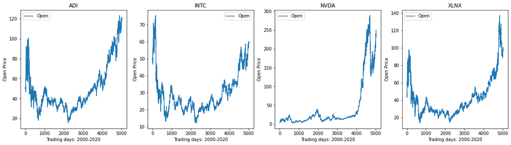

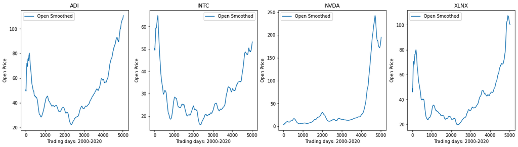

```python
ww = 20
hh = 5

s_keys = list(s_stock_d.keys())
s_values = list(s_stock_d.values())

plt.subplots_adjust(wspace=.2, hspace=.2)
plt.figure(figsize=(ww, hh))
for i in range(len(s_keys)):
    plt.subplot(1, len(keys), i+1)
    values[i]['Open'].plot(label='Open', title = keys[i], legend=True)
    plt.ylabel('Open Price')
    plt.xlabel('Trading days: 2000-2020')

plt.subplots_adjust(wspace=.2, hspace=.2)
plt.figure(figsize=(ww, hh))
for i in range(len(keys)):
# Plot the Adj Close columns
    plt.subplot(1, len(keys), i+1)
    s_values[i]['Open'].plot(label='Open Smoothed', title = keys[i], legend=True)
    plt.ylabel('Open Price')
    plt.xlabel('Trading days: 2000-2020')

plt.show()  # show the plot
```

**Grade cell: `answer_ta` Score: 0.0 / 0.0 (Top)**

```python
# Test cell
### BEGIN HIDDEN TESTS
days = 21
num_trees = 60
datasets, targetsets, featuresets = ta_features_targets_dict(s_stock_d, days)

models = {"Logistic Regression": LogisticRegression(),
          "Random Forest Classifier": RandomForestClassifier(n_jobs=-1, n_estimators=num_trees, random_state=212)}

res = {}
for name, stock_df in datasets.items():
    for model_name, model in models.items():
        # Data Prep
        y = stock_df['pred'].dropna()
        X = stock_df.drop('pred',axis=1)

        # Training and test sets
        train_set_split = int(len(X) * 0.7)
        X_train = X[:train_set_split]
        X_test = X[train_set_split:]
        y_train = y[:train_set_split]
        y_test = y[train_set_split:]

        # Models
        n = name + " "+ model_name + " " + str(days) + "-day window "
        clf = model
        clf.fit(X_train, y_train)
        pred = clf.predict(X_test)

        # Metrics
        accuracy = accuracy_score(y_pred=pred, y_true=y_test)
        precision = precision_score(y_pred=pred, y_true=y_test)
        recall = recall_score(y_pred=pred, y_true=y_test)
        f1 = f1_score(y_pred=pred, y_true=y_test)
        confusion = confusion_matrix(y_pred=pred, y_true=y_test)

        # Results
        res[n] = {"Accuracy": accuracy, "Precision": precision, "Recall": recall, \
                      "F1 Score": f1, "Confusion": confusion}

results = pd.DataFrame.from_dict(res, orient="index")
results = results[["Accuracy", "Precision", "Recall", "F1 Score"]]
print("Example table of results using a " + str(days) + "-day window and ta_alpha = " + str(ta_alpha)+":")
results
### END HIDDEN TESTS
```

```
Example table of results using a 21-day window and ta_alpha = 0.01:
```

|  | Accuracy | Precision | Recall | F1 Score |
| --- | --- | --- | --- | --- |
| ADI Logistic Regression 21-day window | 0.876912 | 0.924362 | 0.920315 | 0.922334 |
| ADI Random Forest Classifier 21-day window | 0.868567 | 0.918349 | 0.915937 | 0.917142 |
| INTC Logistic Regression 21-day window | 0.814325 | 0.872816 | 0.868599 | 0.870702 |
| INTC Random Forest Classifier 21-day window | 0.785814 | 0.919262 | 0.770048 | 0.838065 |
| NVDA Logistic Regression 21-day window | 0.927677 | 0.957735 | 0.954507 | 0.956118 |
| NVDA Random Forest Classifier 21-day window | 0.582754 | 0.969600 | 0.510531 | 0.668874 |
| XLNX Logistic Regression 21-day window | 0.845619 | 0.898522 | 0.884578 | 0.891496 |
| XLNX Random Forest Classifier 21-day window | 0.827538 | 0.887240 | 0.870029 | 0.878550 |

## Question 6

Multiple choice questions. Select all and only that are true.

- A) All things considered, as alpha ($\alpha < 0.5$) approaches zero accuracy scores increase for all stocks.
- B) For $\alpha = 0.2$ (i.e., `ta_alpha = 0.2`), the F1 score for each model with a 7-day window is greater than the corresponding model's F1 score with a 14-day window.
- C) For some $\alpha$, all random forest models have a precision score greater than 0.5 in 7-day, 14-day, and 21-day window horizons.
- D) For some $\alpha$, no logistic regression model has an accuracy score above 0.5 in a 10-day window horizon.
- E) NVDA is the stock whose F1 score is the most sensitive to model choice with alpha = 0.5 (i.e., NVDA is the stock such that the |RF_F1_score - LR_F1_score| is the largest among all stocks given a 7-day, 10-day, 14-day, and 21-day horizon window with `ta_alpha = 0.5`).
- F) The maximum difference in F1 score between Logistic Regression and Random Forests decreases for every stock as the n-day window horizon increases, for n = 7, 10, 14, 21, given a constant alpha of 0.5 (that is, `ta_model = 0.5`).

From the list of possible answers `['A', 'B', 'C', 'D', 'E', 'F']`, complete the next function with a list of your answer(s).

### Q6 Answer:

**Student's answer(Top)**

```python
def ans_six():
    """ Returns a list of your answers.

    Parameters
    ----------
    :ans:  list
        The list of your answers. Elements of :ans: are strings.
    Returns
    -------
    :ans:

    """

    ans = ['C', 'D']
    return ans
```

**Grade cell: `ans_six-test` Score: 1.0 / 1.0 (Top)**

```python
ans = ans_six()
%run -i 'ans_format_test.py'
### BEGIN HIDDEN TESTS

# Test
ans = [x.upper() for x in ans]

print('Question 6: [C, D].\n')

print(" -A is FALSE. Counterexample: INTC RF 7-day window for alpha values between 0.5 to 0.4.\n")

print(" -B is FALSE. NVDIA RF 14-day window (0.564605) > NVDIA RF 7-day window (0.551859)\n")

# Answers E & F
Q6e = [{'Window': '7-day', 'Alpha': 0.5, '(F1: Max |LR-RF|)': 0.2569, 'Stock': 'ADI' },
       {'Window': '10-day', 'Alpha': 0.5, '(F1: Max |LR-RF|)': 0.2199, 'Stock': 'ADI'},
       {'Window': '14-day', 'Alpha': 0.5, '(F1: Max |LR-RF|)': 0.1965, 'Stock': 'NVDA'},
       {'Window': '21-day', 'Alpha': 0.5, '(F1: Max |LR-RF|)': 0.1972, 'Stock': 'NVDA'}]
Q6e_df = pd.DataFrame(Q6e)
print(" -E and F are both FALSE:\n -------------------------------------\n",Q6e_df.to_string(index=False))

if  'C' in ans and 'D' in ans and len(ans) == 2:
    assert True
else:
    raise AssertionError("Incorrect answer.")
del ans
del possible_ans
del results
del Q6e
del Q6e_df
### END HIDDEN TESTS
```

```
Question 6: [C, D].

 -A is FALSE. Counterexample: INTC RF 7-day window for alpha values between 0.5 to 0.4.

 -B is FALSE. NVDIA RF 14-day window (0.564605) > NVDIA RF 7-day window (0.551859)

 -E and F are both FALSE:
 -------------------------------------
  Window  Alpha  (F1: Max |LR-RF|) Stock
  7-day    0.5             0.2569   ADI
 10-day    0.5             0.2199   ADI
 14-day    0.5             0.1965  NVDA
 21-day    0.5             0.1972  NVDA
```

# III. Analysis

The core of the model you developed is taken from ([Basak, Kar, Saha, Khaidem, and Dey 2019](https://www.sciencedirect.com/science/article/abs/pii/S106294081730400X?via%3Dihub)), where they state:

"The focus of the current paper is ... to implement random forests ... to discuss its advantage over non-ensemble techniques" (Basak et al. 2019, p. 554).

A key step in their approach is the use of exponential smoothing as a preprocessing step, and you investigated the effect of using different values for the smoothing factor $\alpha$ for this preprocessing step in the assignment.

"In the current work, we have used exponential smoothing to remove random local variation in the data. A detailed survey of the existing literature does not offer this as a preprocessing step to earlier predictions" (p.558)

Basak et al. report very accurate results, and they argue that the good performance of their methodology is due primarily to ensemble methods, like random forests, working better on non-linear stock data than linear (metric) classifiers, like logistic regression:

"The current methodology performs better than linear classifiers and the reason for this is the inherent non-linearity in the data. Our learning model to [sic] surpass all these metric classifiers in terms of long term prediction" (pp. 558-559).

## Question 7: Short Answer

Do you agree with their analysis? If so, state why. If not, state why not. You should limit your answer to one paragraph (~100 to 200 words). Your answer should be crisp and concise. Imagine you are reporting to the Board of Directors of your firm who will be taking a decision based on your argument.

### Q7 Answer:

**Student's answer Score: 2.0 / 2.0 (Top)**

When looking at the alpha = 0.5 example it is clearly observable that under the same smoothing condition there is no significant better performing and hence more accurate model (comparing the random forest with the “linear” logistic regression). Furthermore, the latter one seems to even outperform the non-linear approach in some cases. The way bigger impact is caused by the exponential smoothing: we can see a clear trend that “more smoothed” (lower alpha) ones tend to perform better in general (not strictly). To conclude I would not agree with the underlying papers. The mentioned inherent non-linearity does not necessarily cause the model choice (it being a linear one or not) to impact the performance a lot. The choice of alpha (and thus level of smoothing) seems to be the more important one.

**Comments:**

Nice!

GENERAL FEEDBACK:

From your analysis, two things should be clear: (i) the effect of the smoothing factor is the dominating factor driving the performance of the model, and (ii) there is otherwise no significant difference between random forests and logistic regression models in this case. Thus, contra Basak et al., good performance is not due primarily to ensemble methods working better on non-linear stock data than linear classifiers, like logistic regression.

Moreover, although it is sometimes asserted that non-linear classification algorithms perform better than linear classifiers because of the “inherent non-linearity in the data”, this is not always true; you have generated in this assignment (the basis for) a counter-example.

The upshot is that “inherent non-linearity” in data does not necessarily imply that a non-linear model will perform better than a linear one.

**Grade cell: `cell-fa682398a02dbc2d` Score: 0.0 / 0.0 (Top)**

```python
# Test for Collaborator policy before submission
%run -i 'collaboration_test.py'
```

Before submitting this notebook, you should do the following steps:

0. **Delete Any New Code You Introduced**: You are likely to have written some code that is computationally expensive, taking many seconds or even some minutes to run. If so, your notebook is very likely to **fail** the **second validation** test if you submit the assignment without first removing all new substantive code blocks introduced by you. What's substantive? If you see: $$\mathtt{In}\ [ * ]:$$ next to a running cell for more than a couple seconds.

1. **Restart Kernel** (Kernel ⟶ Restart and Clear Output)
2. **Run all Cells** (Cell ⟶ Run All)
3. **Validate**: Press the 'Validate' button above.
4. **Save File** (File ⟶ Save and Checkpoint)
5. **Close and Shutdown Kernel** (File ⟶ Close and Halt)